# Fish Microbiome Analysis

Krista Starr

2022-09-21

# Research Questions

- Which gut microbes are aquired from the environment (river water)?
- Which gut microbes are atocthonous to specific species and may be selected for by the host species?
- Are there gut microbes associated with specific trophic levels of the host fish species?

# Setup

Bring in mapping file for all samples and filter out samples unrelated to this research project. Three types of samples are present in these sequencing runs: DEQ, fish fecal, and water samples. This analysis is interested only in fish fecal samples and associated water samples.

```r
#mapping = read.csv("waseem_sampledata.csv")

# make sure negatives all say "negative" in the sample type coloumn
#mapping$sampleType[13]
#mapping$sampleType[13] = "negative"

#mapping$sampleType[33]
#mapping$sampleType[33] = "negative"

#mapping$sampleType[70]
#mapping$sampleType[70] = "negative"

#mapping$sampleType[90]
#mapping$sampleType[90] = "negative"

#sampleTypes = c("negative", "fecal", "water")

#mapping = subset(mapping, mapping$sampleType %in% sampleTypes)

# View head of final mapping file and check out dimensions of the file (number of samples, number of columns)
#head(mapping)
#dim(mapping)

# Save cleaned up mapping file
#write.csv(mapping, "fishMappingFile.csv")
```

I realized that there are 4 negative control sample names that are used twice. I’m going to rename these samples in the main mapping file for this project and in the mapping file for that sequencing run.

```r
# Fecal_pt1_and_DEQ = read.delim("C:\\Users\\14022\\OneDrive - University of Nebraska-Lincoln\\eDNA Rivers project\\Fish_data\\Raw Data\\Fecal-pt1_and-DEQ\\fecalpt1-and-DEQ-complete-edit_miseq.txt")
#
# #View(Fecal_pt1_and_DEQ)
# miseqID_negatives = c("270", "253", "226", "208")
#
# Fecal_pt1_and_DEQ[Fecal_pt1_and_DEQ$miseqID == 270,]
# Fecal_pt1_and_DEQ[Fecal_pt1_and_DEQ$miseqID == 253,]
# Fecal_pt1_and_DEQ[Fecal_pt1_and_DEQ$miseqID == 226,]
# Fecal_pt1_and_DEQ[Fecal_pt1_and_DEQ$miseqID == 208,]
#
# Fecal_pt1_and_DEQ$sampleID[208] = "negative50"
# Fecal_pt1_and_DEQ$sampleID[226] = "negative51"
# Fecal_pt1_and_DEQ$sampleID[251] = "negative52"
# Fecal_pt1_and_DEQ$sampleID[268] = "negative53"

#View(Fecal_pt1_and_DEQ)

#write.csv(Fecal_pt1_and_DEQ, "C:\\Users\\14022\\OneDrive - University of Nebraska-Lincoln\\eDNA Rivers project\\Fish_data\\MicrobiomeAnalysis_KristaAndFederica\\Fecal_pt1_and_DEQ_negFix.csv" )

# Now fix my main mapping file:
#View(mapping)
#
# mapping[mapping$sampleID == "neg16",]
# mapping[26,]
#
# mapping[mapping$sampleID == "neg17",]
# mapping[44,]
#
# mapping[mapping$sampleID == "neg18",]
# mapping[69,]
#
# mapping[mapping$sampleID == "neg19",]
# mapping[86,]
#
# mapping$sampleID[26] = "negative50"
# mapping$sampleID[44] = "negative51"
# mapping$sampleID[69] = "negative52"
# mapping$sampleID[86] = "negative53"

#View(mapping)
#write.csv(mapping, "fishMappingFile.csv")
```

Load in cleaned up mapping file

```r
mapping = read.csv("fishMappingFile.csv")
```

Load packages

```r
library("import")
library("knitr")
library("BiocManager")
library("BiocStyle")
library("ggplot2")
library("gridExtra")
library("Rcpp")
library("dada2")
library("phyloseq")
library("DECIPHER")
library("ape")
library("phangorn")
library("ShortRead")
library("R.utils")
library("MicrobiotaProcess")
```

Find the fastq files.  
In this project there is a challenge because the sequences were done in 4 separate sequencing runs. There are output files in sequencing runs that have the same names as files in another run but represent different samples. I need to change the number at the begining of the Fastq file name from the miSeq ID to the sample ID

## Moving and renaming first sequencing run fastq files

```r
# Sequencing run "Fecal-pt1_and_DEQ"
Fecal_pt1_and_DEQ = read.csv("C:\\Users\\14022\\OneDrive - University of Nebraska-Lincoln\\eDNA Rivers project\\Fish_data\\MicrobiomeAnalysis_KristaAndFederica\\Fecal_pt1_and_DEQ_negFix.csv")

Fecal_pt1_fastq = "C:\\Users\\14022\\OneDrive - University of Nebraska-Lincoln\\eDNA Rivers project\\Fish_data\\Raw Data\\Fecal-pt1_and-DEQ\\fastq"
list.files(Fecal_pt1_fastq)


# sort fastq files by the read type
fnFs_1 = sort(list.files(Fecal_pt1_fastq, pattern="_R1_001.fastq.gz")) #forward reads
fnRs_1 = sort(list.files(Fecal_pt1_fastq, pattern="_R2_001.fastq.gz")) #reverse reads
fnI1s_1 = sort(list.files(Fecal_pt1_fastq, pattern="_I1_001.fastq.gz")) #I1 reads???
fnI2s_1 = sort(list.files(Fecal_pt1_fastq, pattern="_I2_001.fastq.gz")) #I2 reads???
head(fnFs_1)
# Specify the full path to the fnFs and fnRs
fnFs_1 = file.path(Fecal_pt1_fastq, fnFs_1)
fnRs_1 = file.path(Fecal_pt1_fastq, fnRs_1)
head(fnFs_1)

# Create a pathway to store renamed fastq files
fastq_path = "C:\\Users\\14022\\OneDrive - University of Nebraska-Lincoln\\eDNA Rivers project\\Fish_data\\MicrobiomeAnalysis_KristaAndFederica\\fastqFiles"

# copy all the files to my work folder for this project: the number of file names going into file.copy() need to match the number of locations to copy to even if its the same location.
str(fnFs_1)
str(fnRs_1)

for(i in 1:285){
  file.copy(fnFs_1[i],fastq_path)
  file.copy(fnRs_1[i],fastq_path)
}

#list files copied over to working folder
list.files(fastq_path)

#Redefine fnFs and fnRs to be the working folder files
fnFs_1 = sort(list.files(fastq_path, pattern="_R1_001.fastq.gz")) #forward reads
fnRs_1 = sort(list.files(fastq_path, pattern="_R2_001.fastq.gz")) #reverse reads
head(fnFs_1)

# miseqID
miSeqID<- Fecal_pt1_and_DEQ$miseqID
miSeqID

# sampleID
sampleNames = Fecal_pt1_and_DEQ$sampleID
sampleNames

### check everything out
str(fnFs_1)
str(fnRs_1)
str(miSeqID)
str(sampleNames)
# Extract sample names from fastq files, assuming filenames have format: SAMPLENAME_XXX.fastq
fnFs_1 = sort(list.files(Fecal_pt1_fastq, pattern="_R1_001.fastq.gz")) #forward reads
fnRs_1 = sort(list.files(Fecal_pt1_fastq, pattern="_R2_001.fastq.gz")) #reverse reads
fastq_samplenames <- sapply(strsplit(basename(fnFs_1), "_"), `[`, 1)
fastq_samplenames

# are all fastq files in the mapping file?
fastq_samplenames %in% miSeqID
    #all good here!
# do all the miseqids in the mapping file have a corresponding fastq file?
miSeqID %in% fastq_samplenames
    #all good here!

#created correct ordered list of fastq files with the miseqID labeling
miseqFs = file.path(fastq_path, paste0(miSeqID, "_S", miSeqID, "_L001_R1_001.fastq.gz"))
miseqRs = file.path(fastq_path, paste0(miSeqID, "_S", miSeqID, "_L001_R2_001.fastq.gz"))
head(miseqFs)

# Prepare to rename files so that they have the sampleID rather than the miseqID
renamedFs <- file.path(fastq_path, paste0(sampleNames, "_F_sampleNames.fastq.gz"))
renamedRs <- file.path(fastq_path, paste0(sampleNames, "_R_sampleNames.fastq.gz"))
head(renamedRs)

# Rename files
for(i in 1:dim(Fecal_pt1_and_DEQ)[1]){
  file.rename(miseqFs[i],renamedFs[i])
  file.rename(miseqRs[i],renamedRs[i])
}

# make sure all files were named
fnFs_1 = sort(list.files(fastq_path, pattern="_R1_001.fastq.gz")) #forward reads
fnRs_1 = sort(list.files(fastq_path, pattern="_R2_001.fastq.gz")) #reverse reads
head(fnFs_1)
head(fnRs_1)
# All files moved over were sucessfully renamed
```

## Moving and renaming second sequencing run fastq files

```r
# Sequencing run "Fecal-pt2_and_DEQ"
Fecal_pt2_and_DEQ = read.delim("C:\\Users\\14022\\OneDrive - University of Nebraska-Lincoln\\eDNA Rivers project\\Fish_data\\Raw Data\\Fecal-pt2_and-DEQ\\fecalpt2-and-DEQ_edit_miseq.txt")

Fecal_pt2_fastq = "C:\\Users\\14022\\OneDrive - University of Nebraska-Lincoln\\eDNA Rivers project\\Fish_data\\Raw Data\\Fecal-pt2_and-DEQ\\fastq"
list.files(Fecal_pt2_fastq)

# sort fastq files by the read type
fnFs_2 = sort(list.files(Fecal_pt2_fastq, pattern="_R1_001.fastq.gz")) #forward reads
fnRs_2 = sort(list.files(Fecal_pt2_fastq, pattern="_R2_001.fastq.gz")) #reverse reads
fnI1s_2 = sort(list.files(Fecal_pt2_fastq, pattern="_I1_001.fastq.gz")) #I1 reads???
fnI2s_2 = sort(list.files(Fecal_pt2_fastq, pattern="_I2_001.fastq.gz")) #I2 reads???
head(fnFs_2)
# Specify the full path to the fnFs and fnRs
fnFs_2 = file.path(Fecal_pt2_fastq, fnFs_2)
fnRs_2 = file.path(Fecal_pt2_fastq, fnRs_2)
head(fnFs_2)

#Create a pathway to store renamed fastq files
fastq_path = "C:\\Users\\14022\\OneDrive - University of Nebraska-Lincoln\\eDNA Rivers project\\Fish_data\\MicrobiomeAnalysis_KristaAndFederica\\fastqFiles"

# copy all the files to my work folder for this project: the number of file names going into file.copy() need to match the number of locations to copy to even if its the same location.
str(fnFs_2)
str(fnRs_2)

for(i in 1:271){
  file.copy(fnFs_2[i],fastq_path)
  file.copy(fnRs_2[i],fastq_path)
}

#Redefine fnFs and fnRs to be the working folder files
fnFs_2 = sort(list.files(fastq_path, pattern="_R1_001.fastq.gz")) #forward reads
fnRs_2 = sort(list.files(fastq_path, pattern="_R2_001.fastq.gz")) #reverse reads
head(fnFs_2)

# miseqID
miSeqID<- Fecal_pt2_and_DEQ$X
miSeqID

# sampleID
sampleNames = Fecal_pt2_and_DEQ$sampleID
sampleNames

#### Trouble Shooting ####
# need to compare sample ids in the fastq files to those in the mapping files. There is a mismatch between the mapping and the fastq list. I have 271 files and 272 lines in the mapping file. I also know that I have a file for 221 but no info on the mapping file to correspond.
str(fnFs_2)
str(fnRs_2)
str(miSeqID)
str(sampleNames)
# Extract sample names from fastq files, assuming filenames have format: SAMPLENAME_XXX.fastq
fnFs_2 = sort(list.files(Fecal_pt2_fastq, pattern="_R1_001.fastq.gz")) #forward reads
fnRs_2 = sort(list.files(Fecal_pt2_fastq, pattern="_R2_001.fastq.gz")) #reverse reads
fastq_samplenames <- sapply(strsplit(basename(fnFs_2), "_"), `[`, 1)
fastq_samplenames

# are all fastq files in the mapping file?
fastq_samplenames %in% miSeqID
fastq_samplenames[42] # sample 221 is not in the mapping file
# do all the miseqids in the mapping file have a corresponding fastq file?
miSeqID %in% fastq_samplenames
miSeqID[19]
miSeqID[119] # sample 20 and 222 do not have corresponding fastq files?

#I'm going to solve the problem by removing the fastq file for 221 and removing the metadata lines for samples 20 and 222 so that everything lines up
Fecal_pt2_and_DEQ[19,]
Fecal_pt2_and_DEQ[119,]
Fecal_pt2_and_DEQ = Fecal_pt2_and_DEQ[-c(19,119),]
dim(Fecal_pt2_and_DEQ)
##### Back on Track #####

# Recollect miSeqID and sampleIDs
# miseqID
miSeqID<- Fecal_pt2_and_DEQ$X
miSeqID

# sampleID
sampleNames = Fecal_pt2_and_DEQ$sampleID
sampleNames

#created correct ordered list of fastq files with the miseqID labeling
miseqFs = file.path(fastq_path, paste0(miSeqID, "_S", miSeqID, "_L001_R1_001.fastq.gz"))
miseqRs = file.path(fastq_path, paste0(miSeqID, "_S", miSeqID, "_L001_R2_001.fastq.gz"))
head(miseqFs)

# Prepare to rename files so that they have the sampleID rather than the miseqID
renamedFs <- file.path(fastq_path, paste0(sampleNames, "_F_sampleNames.fastq.gz"))
renamedRs <- file.path(fastq_path, paste0(sampleNames, "_R_sampleNames.fastq.gz"))
head(renamedRs)

# Rename files
for(i in 1:dim(Fecal_pt2_and_DEQ)[1]){
  file.rename(miseqFs[i],renamedFs[i])
  file.rename(miseqRs[i],renamedRs[i])
}


# make sure all files were named
fnFs_2 = sort(list.files(fastq_path, pattern="_R1_001.fastq.gz")) #forward reads
fnRs_2 = sort(list.files(fastq_path, pattern="_R2_001.fastq.gz")) #reverse reads
head(fnFs_2)
head(fnRs_2)
# I will manually go in and delete the fastq for sample 221 since the metadata file has no information on it.
```

## Moving and renaming thrid sequencing run fastq files

```r
# Sequencing run "PlatteMicrobe_DEQ_Redos"
PlatteMicrobe_DEQ_Redos = read.delim("C:\\Users\\14022\\OneDrive - University of Nebraska-Lincoln\\eDNA Rivers project\\Fish_data\\Raw Data\\PlatteMicrobe_DEQ_Redos\\plattemicrobe_deq_redos_edit_MISEQ.txt")

PlatteMicrobe_fastq = "C:\\Users\\14022\\OneDrive - University of Nebraska-Lincoln\\eDNA Rivers project\\Fish_data\\Raw Data\\PlatteMicrobe_DEQ_Redos\\fastq"
list.files(PlatteMicrobe_fastq)

# sort fastq files by the read type
fnFs_3 = sort(list.files(PlatteMicrobe_fastq, pattern="_R1_001.fastq.gz")) #forward reads
fnRs_3 = sort(list.files(PlatteMicrobe_fastq, pattern="_R2_001.fastq.gz")) #reverse reads
fnI1s_3 = sort(list.files(PlatteMicrobe_fastq, pattern="_I1_001.fastq.gz")) #I1 reads???
fnI2s_3 = sort(list.files(PlatteMicrobe_fastq, pattern="_I2_001.fastq.gz")) #I2 reads???
head(fnFs_3)
head(fnRs_3)
# Specify the full path to the fnFs and fnRs
fnFs_3 = file.path(PlatteMicrobe_fastq, fnFs_3)
fnRs_3 = file.path(PlatteMicrobe_fastq, fnRs_3)
head(fnFs_3)
head(fnRs_3)

#Create a pathway to store renamed fastq files
fastq_path = "C:\\Users\\14022\\OneDrive - University of Nebraska-Lincoln\\eDNA Rivers project\\Fish_data\\MicrobiomeAnalysis_KristaAndFederica\\fastqFiles"

# copy all the files to my work folder for this project: the number of file names going into file.copy() need to match the number of locations to copy to even if its the same location.
str(fnFs_3)
str(fnRs_3)

for(i in 1:357){
  file.copy(fnFs_3[i],fastq_path)
  file.copy(fnRs_3[i],fastq_path)
}

#Redefine fnFs and fnRs to be the working folder files
fnFs_3 = sort(list.files(fastq_path, pattern="_R1_001.fastq.gz")) #forward reads
fnRs_3 = sort(list.files(fastq_path, pattern="_R2_001.fastq.gz")) #reverse reads
head(fnFs_3)

# miseqID
miSeqID<- PlatteMicrobe_DEQ_Redos$X
miSeqID

# sampleID
sampleNames = PlatteMicrobe_DEQ_Redos$sampleID
sampleNames

# check everything out
str(fnFs_3)
str(fnRs_3)
str(miSeqID)
str(sampleNames)

# Extract sample names from fastq files, assuming filenames have format: SAMPLENAME_XXX.fastq
fnFs_3 = sort(list.files(PlatteMicrobe_fastq, pattern="_R1_001.fastq.gz")) #forward reads
fnRs_3 = sort(list.files(PlatteMicrobe_fastq, pattern="_R2_001.fastq.gz")) #reverse reads
fastq_samplenames <- sapply(strsplit(basename(fnFs_3), "_"), `[`, 1)
fastq_samplenames

# are all fastq files in the mapping file?
fastq_samplenames %in% miSeqID
fastq_samplenames[103]
fastq_samplenames[105]
fastq_samplenames[202] # fastq files for miseqIDs 193, 196, 288 are not in the mapping file
# do all the miseqids in the mapping file have a corresponding fastq file?
miSeqID %in% fastq_samplenames
miSeqID[189]
miSeqID[191]
miSeqID[341]# sample 191,194, and 356 do not have corresponding fastq files?


#I'm going to solve the problem by removing the fastq files for 193, 196, and 288 and removing the metadata lines for samples 191, 194, and 356 so that everything lines up
PlatteMicrobe_DEQ_Redos[189,]
PlatteMicrobe_DEQ_Redos[191,]
PlatteMicrobe_DEQ_Redos[341,]
PlatteMicrobe_DEQ_Redos = PlatteMicrobe_DEQ_Redos[-c(189,191,341),]
dim(PlatteMicrobe_DEQ_Redos)

# Recollect miSeqID and sampleIDs
# miseqID
miSeqID<- PlatteMicrobe_DEQ_Redos$X
miSeqID

# sampleID
sampleNames = PlatteMicrobe_DEQ_Redos$sampleID
sampleNames

#created correct ordered list of fastq files with the miseqID labeling
miseqFs = file.path(fastq_path, paste0(miSeqID, "_S", miSeqID, "_L001_R1_001.fastq.gz"))
miseqRs = file.path(fastq_path, paste0(miSeqID, "_S", miSeqID, "_L001_R2_001.fastq.gz"))
head(miseqFs)

# Prepare to rename files so that they have the sampleID rather than the miseqID
renamedFs <- file.path(fastq_path, paste0(sampleNames, "_F_sampleNames.fastq.gz"))
renamedRs <- file.path(fastq_path, paste0(sampleNames, "_R_sampleNames.fastq.gz"))
head(renamedRs)

# Rename files
for(i in 1:dim(PlatteMicrobe_DEQ_Redos)[1]){
  file.rename(miseqFs[i],renamedFs[i])
  file.rename(miseqRs[i],renamedRs[i])
}

# make sure all files were named
fnFs_3 = sort(list.files(fastq_path, pattern="_R1_001.fastq.gz")) #forward reads
fnRs_3 = sort(list.files(fastq_path, pattern="_R2_001.fastq.gz")) #reverse reads
head(fnFs_3)
head(fnRs_3)
# I will manually go in and delete the fastq for samples 191,194, and 356 since the metadata file has no information on it.
```

At this point I have all the fastq samples renamed to the format “sampleName_F_sampleNames.fastq.gz” or “sampleName_R_sampleNames.fastq.gz” and located in the `fastq_path`. Now I need to use the mapping file that is filtered to have only fish fecal samples and water samples to remove all fastq files from DEQ samples which I am not interested in.

```r
# PROBLEM: some samples have names like 100_3, these are all called 100 using this code.
  # in addition this is true in the fastq file names as well as the mapping file.
  # I'm just going to manually rename the files and change the mapping file so that any sample with an underscore has a dash instead.


# View(mapping)
# approach: create a list of file names that I want to keep to coppy over to a new folder.
sampleID = mapping$sampleID
sampleID

# list of files I want to coppy
keepFastqFs = file.path(fastq_path, paste0(sampleID, "_F_sampleNames.fastq.gz"))
keepFastqRs = file.path(fastq_path, paste0(sampleID, "_R_sampleNames.fastq.gz"))
keepFastqFs

# redefine fastq_path to be the final location
fastq_path = "C:\\Users\\14022\\OneDrive - University of Nebraska-Lincoln\\eDNA Rivers project\\Fish_data\\MicrobiomeAnalysis_KristaAndFederica\\fastqFiles_final"

# Extract sample names from fastq files, assuming filenames have format: SAMPLENAME_XXX.fastq
fnFs = sort(list.files(fastq_path, pattern="_F_sampleNames.fastq.gz")) #forward reads
fnRs = sort(list.files(fastq_path, pattern="_R_sampleNames.fastq.gz")) #reverse reads
fastq_samplenames <- sapply(strsplit(basename(fnFs), "_"), `[`, 1)
fastq_samplenames

# are they all there?
sampleID %in% fastq_samplenames # neg1-4 weren't coppied over?,
sampleID[1:4] #These aren't in the sequencing runs I'm looking at. no worries
fastq_samplenames %in% sampleID

# Coppy over keep fastqs to the final location
str(keepFastqFs)
str(keepFastqRs)

for(i in 1:336){
  file.copy(keepFastqFs[i],fastq_path)
  file.copy(keepFastqRs[i],fastq_path)
  }
```

Now the folder “fastqFiles_final” contains the fastq files of only samples of interest that are renamed from the miseqID format to the sampleID format.

Give a project name. This will be included in the file names of many output files

```r
project_name = "FishMicrobiome"
```

Give the full path to the directory/folder containing your dereplicated fastq files

```r
fastq_files = "C:\\Users\\14022\\OneDrive - University of Nebraska-Lincoln\\eDNA Rivers project\\Fish_data\\MicrobiomeAnalysis_KristaAndFederica\\fastqFiles_final"
```

# DADA2 Pipeline

filter and trim fastq files

```r
fnFs <- sort(list.files(fastq_files, pattern="_F_sampleNames.fastq")) #forward reads
fnRs <- sort(list.files(fastq_files, pattern="_R_sampleNames.fastq")) #reverse reads
fnFs
```

```
##   [1] "100_F_sampleNames.fastq"           "101_F_sampleNames.fastq"
##   [3] "102_F_sampleNames.fastq"           "103_F_sampleNames.fastq"
##   [5] "104_F_sampleNames.fastq"           "105_F_sampleNames.fastq"
##   [7] "105_F_sampleNames.fastq.gz"        "106_F_sampleNames.fastq"
##   [9] "106_F_sampleNames.fastq.gz"        "107_F_sampleNames.fastq"
##  [11] "107_F_sampleNames.fastq.gz"        "108_F_sampleNames.fastq"
##  [13] "108_F_sampleNames.fastq.gz"        "109_F_sampleNames.fastq"
##  [15] "109_F_sampleNames.fastq.gz"        "110-1_F_sampleNames.fastq"
##  [17] "110-1_F_sampleNames.fastq.gz"      "110-10_F_sampleNames.fastq"
##  [19] "110-10_F_sampleNames.fastq.gz"     "110-2_F_sampleNames.fastq"
##  [21] "110-2_F_sampleNames.fastq.gz"      "110-3_F_sampleNames.fastq"
##  [23] "110-3_F_sampleNames.fastq.gz"      "110-5_F_sampleNames.fastq"
##  [25] "110-5_F_sampleNames.fastq.gz"      "110-6_F_sampleNames.fastq"
##  [27] "110-6_F_sampleNames.fastq.gz"      "110-8_F_sampleNames.fastq"
##  [29] "110-8_F_sampleNames.fastq.gz"      "110-9_F_sampleNames.fastq"
```

[output cut: 313 more lines]

Extract sample names, assuming filenames have format: SAMPLENAME_XXX.fastq

```r
sampleNames <- sapply(strsplit(fnFs, "_"), `[`, 1)
sampleNames
```

```
##   [1] "100"        "101"        "102"        "103"        "104"
##   [6] "105"        "105"        "106"        "106"        "107"
##  [11] "107"        "108"        "108"        "109"        "109"
##  [16] "110-1"      "110-1"      "110-10"     "110-10"     "110-2"
##  [21] "110-2"      "110-3"      "110-3"      "110-5"      "110-5"
##  [26] "110-6"      "110-6"      "110-8"      "110-8"      "110-9"
##  [31] "110-9"      "110"        "110"        "111-1"      "111-1"
##  [36] "111-2"      "111-2"      "111-3"      "111-3"      "111-4"
##  [41] "111-4"      "111-5"      "111-5"      "111-7"      "111-7"
##  [46] "111"        "111"        "112-1"      "112-1"      "112-2"
##  [51] "112-2"      "112-3"      "112-3"      "112-4"      "112-4"
##  [56] "112-5"      "112-5"      "112-7"      "112-7"      "112"
##  [61] "112"        "113-1"      "113-1"      "113-10"     "113-10"
##  [66] "113-11"     "113-11"     "113-12"     "113-12"     "113-3"
##  [71] "113-3"      "113-4"      "113-4"      "113-5"      "113-5"
```

[output cut: 116 more lines]

Specify the full path to the fnFs and fnRs

```r
fnFs <- file.path(fastq_files, fnFs)
fnRs <- file.path(fastq_files, fnRs)
fnFs[1:3]
```

```
## [1] "C:\\Users\\14022\\OneDrive - University of Nebraska-Lincoln\\eDNA Rivers project\\Fish_data\\MicrobiomeAnalysis_KristaAndFederica\\fastqFiles_final/100_F_sampleNames.fastq"
## [2] "C:\\Users\\14022\\OneDrive - University of Nebraska-Lincoln\\eDNA Rivers project\\Fish_data\\MicrobiomeAnalysis_KristaAndFederica\\fastqFiles_final/101_F_sampleNames.fastq"
## [3] "C:\\Users\\14022\\OneDrive - University of Nebraska-Lincoln\\eDNA Rivers project\\Fish_data\\MicrobiomeAnalysis_KristaAndFederica\\fastqFiles_final/102_F_sampleNames.fastq"
```

```r
fnRs[1:3]
```

```
## [1] "C:\\Users\\14022\\OneDrive - University of Nebraska-Lincoln\\eDNA Rivers project\\Fish_data\\MicrobiomeAnalysis_KristaAndFederica\\fastqFiles_final/100_R_sampleNames.fastq"
## [2] "C:\\Users\\14022\\OneDrive - University of Nebraska-Lincoln\\eDNA Rivers project\\Fish_data\\MicrobiomeAnalysis_KristaAndFederica\\fastqFiles_final/101_R_sampleNames.fastq"
## [3] "C:\\Users\\14022\\OneDrive - University of Nebraska-Lincoln\\eDNA Rivers project\\Fish_data\\MicrobiomeAnalysis_KristaAndFederica\\fastqFiles_final/102_R_sampleNames.fastq"
```

Unzip fastqfiles

```r
str(fnFs)
str(fnRs)

for(i in 1:332){
  gunzip(fnFs[i])
  gunzip(fnRs[i])
}
```

Need to reset `fnFs` and `fnRs` to be the fastq files unzipped

```r
fnFs <- sort(list.files(fastq_files, pattern="_F_sampleNames.fastq")) #forward reads
fnRs <- sort(list.files(fastq_files, pattern="_R_sampleNames.fastq")) #reverse reads
fnFs[1:3]
```

```
## [1] "100_F_sampleNames.fastq" "101_F_sampleNames.fastq"
## [3] "102_F_sampleNames.fastq"
```

```r
fnFs <- file.path(fastq_files, fnFs)
fnRs <- file.path(fastq_files, fnRs)
fnFs[1:3]
```

```
## [1] "C:\\Users\\14022\\OneDrive - University of Nebraska-Lincoln\\eDNA Rivers project\\Fish_data\\MicrobiomeAnalysis_KristaAndFederica\\fastqFiles_final/100_F_sampleNames.fastq"
## [2] "C:\\Users\\14022\\OneDrive - University of Nebraska-Lincoln\\eDNA Rivers project\\Fish_data\\MicrobiomeAnalysis_KristaAndFederica\\fastqFiles_final/101_F_sampleNames.fastq"
## [3] "C:\\Users\\14022\\OneDrive - University of Nebraska-Lincoln\\eDNA Rivers project\\Fish_data\\MicrobiomeAnalysis_KristaAndFederica\\fastqFiles_final/102_F_sampleNames.fastq"
```

```r
fnRs[1:3]
```

```
## [1] "C:\\Users\\14022\\OneDrive - University of Nebraska-Lincoln\\eDNA Rivers project\\Fish_data\\MicrobiomeAnalysis_KristaAndFederica\\fastqFiles_final/100_R_sampleNames.fastq"
## [2] "C:\\Users\\14022\\OneDrive - University of Nebraska-Lincoln\\eDNA Rivers project\\Fish_data\\MicrobiomeAnalysis_KristaAndFederica\\fastqFiles_final/101_R_sampleNames.fastq"
## [3] "C:\\Users\\14022\\OneDrive - University of Nebraska-Lincoln\\eDNA Rivers project\\Fish_data\\MicrobiomeAnalysis_KristaAndFederica\\fastqFiles_final/102_R_sampleNames.fastq"
```

Quality plots will allow you to determine how to truncate your reads

- can change to view more than two plots at a time example: plotQualityProfile(fnFs[1:10])
- be sure to know if you are looking at a negative control!
- Your Q score plots should not look as “good” on a negative vs positive vs sample

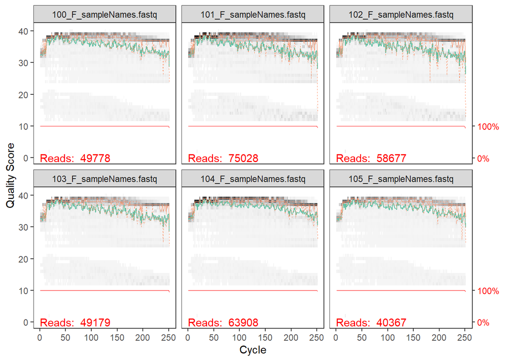

```r
plotQualityProfile(fnFs[1:6])
```

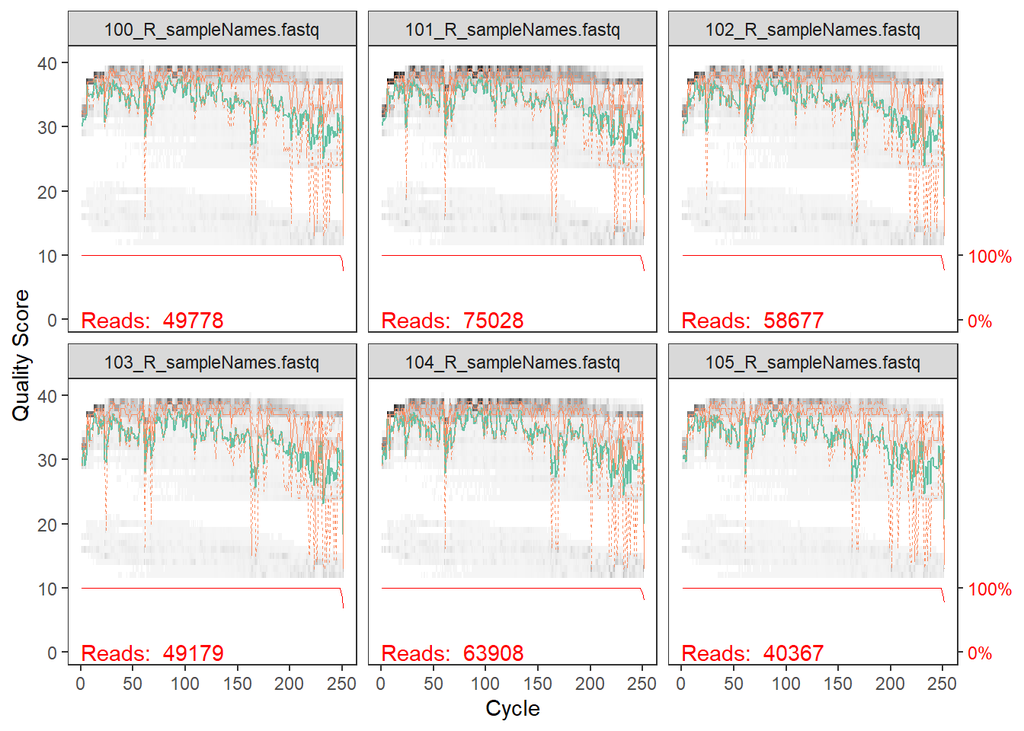

```r
plotQualityProfile(fnRs[1:6])
```

Based on these quality profiles I will try trimming the reads at 240 on the forward read and 160 on the reverse reads. The rest of the DADA2 pipeline will be done on HCC crane. Output files will be uploaded.

## Assess Negative Controls

After starting the DADA2 pipeline I noticed that many of the negative controls seem to have concerningly large read counts.

```r
load("C:\\Users\\14022\\OneDrive - University of Nebraska-Lincoln\\eDNA Rivers project\\Fish_data\\MicrobiomeAnalysis_KristaAndFederica\\fishMicrobe_out.rds")
out
```

```
##                                reads.in reads.out
## 100_F_sampleNames.fastq           49778     41658
## 101_F_sampleNames.fastq           75028     61095
## 102_F_sampleNames.fastq           58677     47719
## 103_F_sampleNames.fastq           49179     40766
## 104_F_sampleNames.fastq           63908     56467
## 105_F_sampleNames.fastq           40367     34342
## 106_F_sampleNames.fastq           37848     32980
## 107_F_sampleNames.fastq           67270     57048
## 108_F_sampleNames.fastq           69566     59255
## 109_F_sampleNames.fastq           41499     35463
## 110_F_sampleNames.fastq           67966     54596
## 110-1_F_sampleNames.fastq          6231      5373
## 110-10_F_sampleNames.fastq        18586     16941
## 110-2_F_sampleNames.fastq         37807     32286
## 110-3_F_sampleNames.fastq         21391     19046
## 110-5_F_sampleNames.fastq         25521     23002
## 110-6_F_sampleNames.fastq         22352     20150
## 110-8_F_sampleNames.fastq         21625     19534
## 110-9_F_sampleNames.fastq         19630     16428
## 111_F_sampleNames.fastq           77886     65506
## 111-1_F_sampleNames.fastq         15533     13438
## 111-2_F_sampleNames.fastq         17128     14541
## 111-3_F_sampleNames.fastq         12305     10265
## 111-4_F_sampleNames.fastq         22427     19429
## 111-5_F_sampleNames.fastq         12698     11111
## 111-7_F_sampleNames.fastq         19150     16955
## 112_F_sampleNames.fastq             654       314
## 112-1_F_sampleNames.fastq         13163     11804
## 112-2_F_sampleNames.fastq         20266     17679
## 112-3_F_sampleNames.fastq         23711     20792
## 112-4_F_sampleNames.fastq         22544     19599
## 112-5_F_sampleNames.fastq         12342     10973
## 112-7_F_sampleNames.fastq         24836     21388
## 113_F_sampleNames.fastq           55375     44785
## 113-1_F_sampleNames.fastq         13161     11683
## 113-10_F_sampleNames.fastq        35486     31717
## 113-11_F_sampleNames.fastq        24548     21517
## 113-12_F_sampleNames.fastq        24909     21713
## 113-3_F_sampleNames.fastq          8336      7213
```

[output cut: 278 more lines]

```
## negative39_F_sampleNames.fastq     1084       166
## negative40_F_sampleNames.fastq     1702       538
## negative41_F_sampleNames.fastq     1493       332
## negative42_F_sampleNames.fastq     1116       421
## negative43_F_sampleNames.fastq     4665      1351
## negative44_F_sampleNames.fastq     2191       367
## negative45_F_sampleNames.fastq     2144       254
## negative46_F_sampleNames.fastq     2749       231
## negative47_F_sampleNames.fastq     1410       434
## negative48_F_sampleNames.fastq     2961      1015
## negative49_F_sampleNames.fastq     3104       441
## negative50_F_sampleNames.fastq      658       522
## negative51_F_sampleNames.fastq      400       321
## negative52_F_sampleNames.fastq      137        78
## negative53_F_sampleNames.fastq      172       152
```

```r
str(out)
```

```
##  num [1:332, 1:2] 49778 75028 58677 49179 63908 ...
##  - attr(*, "dimnames")=List of 2
##   ..$ : chr [1:332] "100_F_sampleNames.fastq" "101_F_sampleNames.fastq" "102_F_sampleNames.fastq" "103_F_sampleNames.fastq" ...
##   ..$ : chr [1:2] "reads.in" "reads.out"
```

```r
outTable = as.data.frame(out)
names(outTable)
```

```
## [1] "reads.in"  "reads.out"
```

```r
dim(outTable)
```

```
## [1] 332   2
```

```r
# these are the negative controls
outTable[289:332,]
```

```
##                                reads.in reads.out
## neg10_F_sampleNames.fastq           206       143
## neg11_F_sampleNames.fastq           247       141
## neg12_F_sampleNames.fastq           179       112
## neg13_F_sampleNames.fastq          7047      6155
## neg14_F_sampleNames.fastq         11518     10352
## neg15_F_sampleNames.fastq           363       231
## neg16_F_sampleNames.fastq           365       277
## neg17_F_sampleNames.fastq           140       104
## neg18_F_sampleNames.fastq           231       174
## neg19_F_sampleNames.fastq           313       274
## neg20_F_sampleNames.fastq           328       233
## neg25_F_sampleNames.fastq          6305      5927
## neg27_F_sampleNames.fastq           642       543
## neg28_F_sampleNames.fastq          1194      1045
## neg29_F_sampleNames.fastq           953       844
## neg30_F_sampleNames.fastq         38394     35608
## neg31_F_sampleNames.fastq          1691      1531
## neg32_F_sampleNames.fastq          1000       850
## neg33_F_sampleNames.fastq          1003       903
## neg34_F_sampleNames.fastq          2814      2567
## neg5_F_sampleNames.fastq            512       350
## neg6_F_sampleNames.fastq            350       209
## neg7_F_sampleNames.fastq            368       229
## neg8_F_sampleNames.fastq           1865      1462
## neg9_F_sampleNames.fastq            562       431
## negative35_F_sampleNames.fastq     1759      1004
## negative36_F_sampleNames.fastq     1651       808
## negative37_F_sampleNames.fastq     4635      1965
## negative38_F_sampleNames.fastq     3241      1963
## negative39_F_sampleNames.fastq     1084       166
## negative40_F_sampleNames.fastq     1702       538
## negative41_F_sampleNames.fastq     1493       332
## negative42_F_sampleNames.fastq     1116       421
## negative43_F_sampleNames.fastq     4665      1351
## negative44_F_sampleNames.fastq     2191       367
## negative45_F_sampleNames.fastq     2144       254
## negative46_F_sampleNames.fastq     2749       231
## negative47_F_sampleNames.fastq     1410       434
## negative48_F_sampleNames.fastq     2961      1015
## negative49_F_sampleNames.fastq     3104       441
## negative50_F_sampleNames.fastq      658       522
## negative51_F_sampleNames.fastq      400       321
## negative52_F_sampleNames.fastq      137        78
## negative53_F_sampleNames.fastq      172       152
```

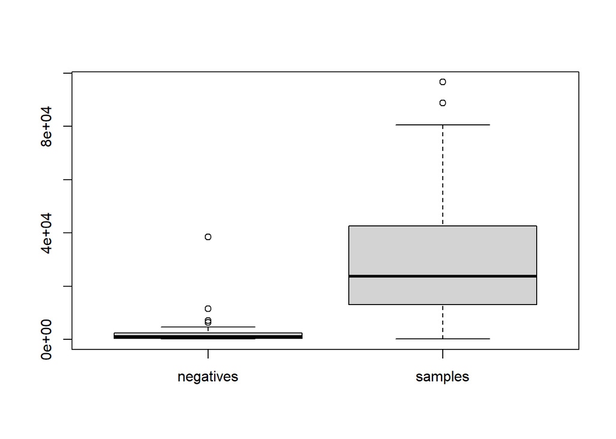

```r
boxplot(outTable$reads.in[289:332], outTable$reads.in[1:288], names = c("negatives", "samples"))
```

```r
# I don't have Ester's lab notebook containing the first sequencing run work. However her mapping files for sequencing runs 2 and 3 were acurate so I will use the mapping file for sequencing run 1 to look at the negative controls for each plate in the run
run1plate1 = c("neg5", "neg6", "neg7", "neg8")
outTable[309:312,]
```

```
##                          reads.in reads.out
## neg5_F_sampleNames.fastq      512       350
## neg6_F_sampleNames.fastq      350       209
## neg7_F_sampleNames.fastq      368       229
## neg8_F_sampleNames.fastq     1865      1462
```

```r
run1plate2 = c("neg9", "neg10", "neg11", "neg12", "neg13", "neg14")
rows = c(313, 289, 290, 291, 292, 293)
outTable[rows,]
```

```
##                           reads.in reads.out
## neg9_F_sampleNames.fastq       562       431
## neg10_F_sampleNames.fastq      206       143
## neg11_F_sampleNames.fastq      247       141
## neg12_F_sampleNames.fastq      179       112
## neg13_F_sampleNames.fastq     7047      6155
## neg14_F_sampleNames.fastq    11518     10352
```

```r
run1plate3 = c("neg15", "negative50", "negative51", "negative52", "negative53")
rows = c(293, 329, 330, 331, 332)
outTable[rows,]
```

```
##                                reads.in reads.out
## neg14_F_sampleNames.fastq         11518     10352
## negative50_F_sampleNames.fastq      658       522
## negative51_F_sampleNames.fastq      400       321
## negative52_F_sampleNames.fastq      137        78
## negative53_F_sampleNames.fastq      172       152
```

```r
# The samples in "Fecal_pt2_and_DEQ" that occupy miseqIDs 1-96 are all DEQ samples. I have not found anything in the lab notebook to crossrefference too but These negative controls are not relavant to the current study because they are not from a plate with samples of interest.
run2plate1 = c("neg16", "neg17", "neg18", "neg19", "neg20")
outTable[295:299,]
```

```
##                           reads.in reads.out
## neg16_F_sampleNames.fastq      365       277
## neg17_F_sampleNames.fastq      140       104
## neg18_F_sampleNames.fastq      231       174
## neg19_F_sampleNames.fastq      313       274
## neg20_F_sampleNames.fastq      328       233
```

```r
# Confirmed through comparison to lab notebook: There is a plate of samples in "Fecal_pt2_and_DEQ" that has only these negative controls, the plate is 11-6-2019: Fecal 8/5-8/14. Neg 26 was removed above because there was no fastq file for that miseq ID in the shared folder.
run2plate3 = c("neg25", "neg26", "neg27", "neg28", "neg29", "neg30")
outTable[300:304,]
```

```
##                           reads.in reads.out
## neg25_F_sampleNames.fastq     6305      5927
## neg27_F_sampleNames.fastq      642       543
## neg28_F_sampleNames.fastq     1194      1045
## neg29_F_sampleNames.fastq      953       844
## neg30_F_sampleNames.fastq    38394     35608
```

```r
# Confirmed through comparison to lab notebook: There is a plate of samples in "Fecal_pt2_and_DEQ" that has only these negative controls. The plate is 11-08-2019, Fecal+DEQs500+600 (primer4).
run2plate4 = c("neg31", "neg32", "neg33", "neg34")
outTable[305:308,]
```

```
##                           reads.in reads.out
## neg31_F_sampleNames.fastq     1691      1531
## neg32_F_sampleNames.fastq     1000       850
## neg33_F_sampleNames.fastq     1003       903
## neg34_F_sampleNames.fastq     2814      2567
```

```r
# Confirmed through comparison to lab notebook: There is a plate of samples in "PlatteMicrobe_DEQ_Redos" That has only these negative controls. The plate is Platte Microbe Samples dated 12-02-2019. I presume it was primer plate 1 based on the associated miseqIDs
run3plate1 = c("Negative35", "Negative36", "Negative37", "Negative38")
outTable[314:317,]
```

```
##                                reads.in reads.out
## negative35_F_sampleNames.fastq     1759      1004
## negative36_F_sampleNames.fastq     1651       808
## negative37_F_sampleNames.fastq     4635      1965
## negative38_F_sampleNames.fastq     3241      1963
```

```r
# Confirmed through comparison to lab notebook: Plate 1-8-2020, DEQ Straggling Samples + 600s primer 2 is part of sequencing run "PlatteMicrobe_DEQ_Redos". All samples on this plate are DEQ samples and irrelevant to the current study
run3plate2 = c("Negative 39", "Negative40", "Negative41", "Negative42")
outTable[318:321,]
```

```
##                                reads.in reads.out
## negative39_F_sampleNames.fastq     1084       166
## negative40_F_sampleNames.fastq     1702       538
## negative41_F_sampleNames.fastq     1493       332
## negative42_F_sampleNames.fastq     1116       421
```

```r
# Confirmed through comparison to lab notebook: Plate 1-10-2020, DEQ strag+600+700 primer 3 is part of sequencing run "PlatteMicrobe_DEQ_Redos". All samples in this plate are DEQ samples and irrelevant to the current study.
run3plate3 = c("Negative43", "Negative44", "Negative45", "Negative46")
outTable[322:325,]
```

```
##                                reads.in reads.out
## negative43_F_sampleNames.fastq     4665      1351
## negative44_F_sampleNames.fastq     2191       367
## negative45_F_sampleNames.fastq     2144       254
## negative46_F_sampleNames.fastq     2749       231
```

```r
# Confirmed through comparison to lab notebook: Plate 1-16-2020, DEQ 700s + Redos from other plates is part of sequencing run "PlatteMicrobe_DEQ_Redos". There are a few samples of interest in this plate
run3plate4 = c("Negative47", "Negative48", "Negative49")
outTable[326:328,]
```

```
##                                reads.in reads.out
## negative47_F_sampleNames.fastq     1410       434
## negative48_F_sampleNames.fastq     2961      1015
## negative49_F_sampleNames.fastq     3104       441
```

# Plate by Plate analysis of negative controls

In crane I ran the DADA2 pipeline on plates individually. Here I’m going to make phyloseq objects and dig into what the negative controls look like for each plate. Based on this information we will decide which plates are useable and which are not.

-[Joey711 phyloseq tutorial](https://joey711.github.io/phyloseq/import-data.html)

## Fecal_pt1_and_DEQ plate 3: Fecal Samples

```r
##final phyloseq Object

# loading in these files directly from their text files

meta = read.csv("C:\\Users\\14022\\OneDrive - University of Nebraska-Lincoln\\eDNA Rivers project\\Fish_data\\MicrobiomeAnalysis_KristaAndFederica\\Fecal_pt1_and_DEQ_negFix.csv")
row.names(meta) = meta$miseqID

asv_tab = read.table("D:\\fish gut\\fecal_pt1_and_deq_plate3\\Analysis\\ASVs_counts.txt")
colnames(asv_tab)
dim(asv_tab)
# need to name the samples without the X prefix Need to make sure I rename the colums correctly
meta$miseqID[meta$miseqID >= 193]
# creating a little dataframe to compare the col names to the sample names pulled from the meta data file.
check = data.frame(asv_tab = colnames(asv_tab), meta = meta$miseqID[meta$miseqID >= 193])
check$meta = as.character(check$meta)
check$metaTransform = paste0("X", check$meta)
# are all the sample names in the ASV_tab in the list of sample names pulled from the meta data frame? And are they all in exactly the same order?
check$asv_tab %in% check$metaTransform
check$asv_tab == check$metaTransform
# rename the columns in the asv_tab.
colnames(asv_tab) = meta$miseqID[meta$miseqID >= 193]
# ASV table should be a matrix to go to phyloseq seamlessly.
class(asv_tab)
asv_tab = as.matrix(asv_tab)
asv_tab[1:5 , 1:5]

# Taxa table should be a character matrix to go to phyloseq seamlessly.
asv_tax = read.delim("D:\\fish gut\\fecal_pt1_and_deq_plate3\\Analysis\\ASVs_taxonomy.txt")
head(asv_tax)
class(asv_tax)
asv_tax = as.matrix(asv_tax)
head(asv_tax)

tree = read_tree("D:\\fish gut\\fecal_pt1_and_deq_plate3\\Analysis\\ASVs.phylip.tre")

# There is a conflict with the `tax_table()` function when you have both phyloseq and MicrobiotaProcess loaded. I will need to specify which function I am refering to by calling `phyloseq::tax_table()`.
ps_fecal_pt1_plate3 = phyloseq(otu_table(asv_tab, taxa_are_rows=TRUE),
                        sample_data(meta),
                               phyloseq::tax_table(asv_tax),
                               phy_tree(tree))

save(ps_fecal_pt1_plate3, file= "ps_fecal_pt1_plate3.RData")
```

Load in phyloseq object

```r
load("ps_fecal_pt1_plate3.RData")
```

Reads in negatives vs reads in samples

```r
Fecal_pt1_and_DEQ = read.csv("C:\\Users\\14022\\OneDrive - University of Nebraska-Lincoln\\eDNA Rivers project\\Fish_data\\MicrobiomeAnalysis_KristaAndFederica\\Fecal_pt1_and_DEQ_negFix.csv")

track_reads = read.csv("D:\\fish gut\\fecal_pt1_and_deq_plate3\\track_reads.csv")
head(track_reads)
```

```
##     X input filtered denoisedF denoisedR merged nonchim
## 1 193  6231     5373      4855      4945   4284    4257
## 2 194 37807    32286     31529     31684  30102   29680
## 3 195 21391    19046     18682     18820  18078   18078
## 4 196 25521    23002     22400     22515  21026   21013
## 5 197   363      231       179       200    178     178
## 6 198 22352    20150     18648     19265  16441   16441
```

```r
row.names(track_reads) = track_reads$X
head(track_reads)
```

```
##       X input filtered denoisedF denoisedR merged nonchim
## 193 193  6231     5373      4855      4945   4284    4257
## 194 194 37807    32286     31529     31684  30102   29680
## 195 195 21391    19046     18682     18820  18078   18078
## 196 196 25521    23002     22400     22515  21026   21013
## 197 197   363      231       179       200    178     178
## 198 198 22352    20150     18648     19265  16441   16441
```

```r
# head(Fecal_pt1_and_DEQ)

negatives = Fecal_pt1_and_DEQ$miseqID[Fecal_pt1_and_DEQ$sample_or_control == "negative"]
negatives = negatives[negatives >= 193]
Fecal_pt1_and_DEQ[Fecal_pt1_and_DEQ$miseqID %in% negatives , 1:4]
```

```
##       X miseqID   sampleID sample_or_control
## 197 197     197      neg15          negative
## 208 208     208 negative50          negative
## 226 226     226 negative51          negative
## 251 251     253 negative52          negative
## 268 268     270 negative53          negative
```

```r
samples = Fecal_pt1_and_DEQ$miseqID[Fecal_pt1_and_DEQ$sample_or_control == "sample"]
samples = samples[samples >= 193]
# Fecal_pt1_and_DEQ[Fecal_pt1_and_DEQ$miseqID %in% samples, ]

negatives
```

```
## [1] 197 208 226 253 270
```

```r
samples
```

```
##  [1] 193 194 195 196 198 199 200 201 202 203 204 205 206 207 209 210 211 212 213
## [20] 214 215 216 217 218 219 220 221 222 223 224 225 227 228 229 230 231 232 233
## [39] 234 235 236 237 238 239 240 241 242 243 244 245 246 247 248 251 252 254 255
## [58] 256 257 258 259 260 261 262 263 264 265 266 267 268 269 271 272 273 274 275
## [77] 276 277 278 279 280 281 282 284 285 286 287 288
```

```r
negative_data = track_reads[track_reads$X %in% negatives , ]
negative_data
```

```
##       X input filtered denoisedF denoisedR merged nonchim
## 197 197   363      231       179       200    178     178
## 208 208   658      522       400       434    374     374
## 226 226   400      321       306       299    294     294
## 253 253   137       78        58        53     49      49
## 270 270   172      152       131       132    120     120
```

```r
sample_data = track_reads[track_reads$X %in% samples , ]

# compare average reads at input (before all processing)
mean(negative_data$input)
```

```
## [1] 346
```

```r
sd(negative_data$input)
```

```
## [1] 208.8696
```

```r
mean(sample_data$input)
```

```
## [1] 16267.74
```

```r
sd(sample_data$input)
```

```
## [1] 8482.608
```

```r
mean(negative_data$input) / mean(sample_data$input)
```

```
## [1] 0.02126909
```

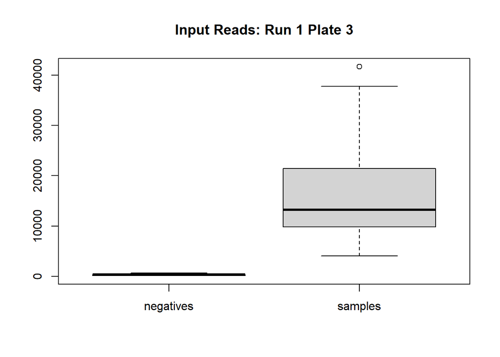

```r
boxplot(negative_data$input, sample_data$input, names = c("negatives", "samples"), main = "Input Reads: Run 1 Plate 3")
```

```r
# compare average reads at nochim (at end of DADA2 pipeline)
mean(negative_data$nonchim)
```

```
## [1] 203
```

```r
sd(negative_data$nonchim)
```

```
## [1] 131.103
```

```r
mean(sample_data$nonchim)
```

```
## [1] 12426.7
```

```r
sd(sample_data$nonchim)
```

```
## [1] 6797.032
```

```r
mean(negative_data$nonchim) / mean(sample_data$nonchim)
```

```
## [1] 0.01633579
```

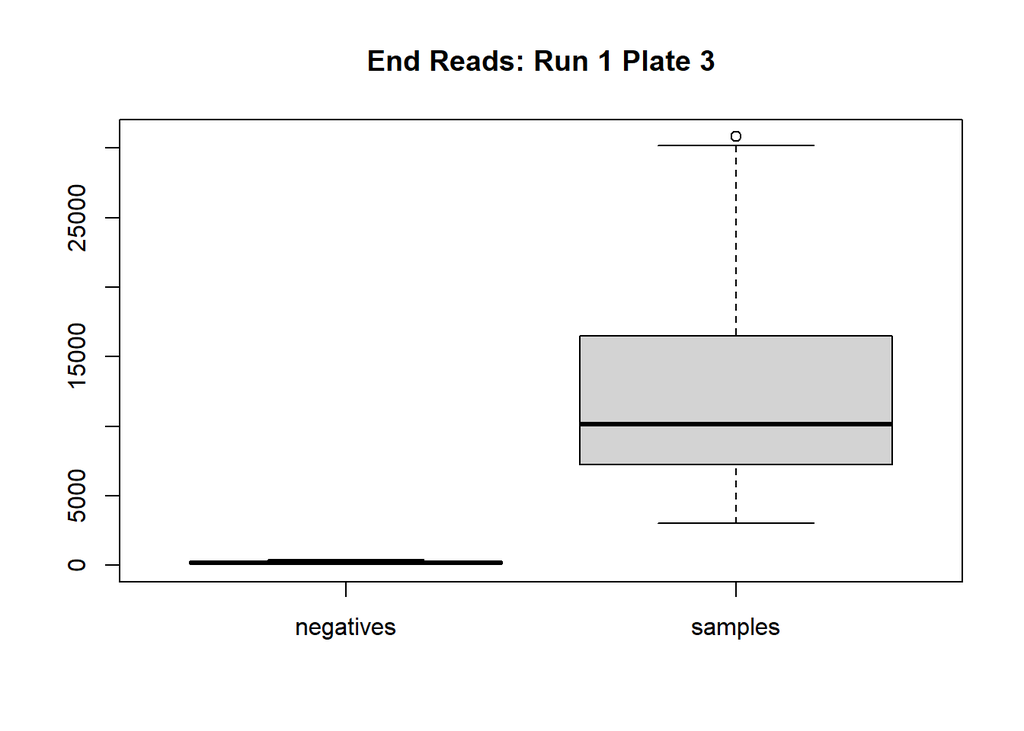

```r
boxplot(negative_data$nonchim, sample_data$nonchim, names=c("negatives", "samples"), main = "End Reads: Run 1 Plate 3")
```

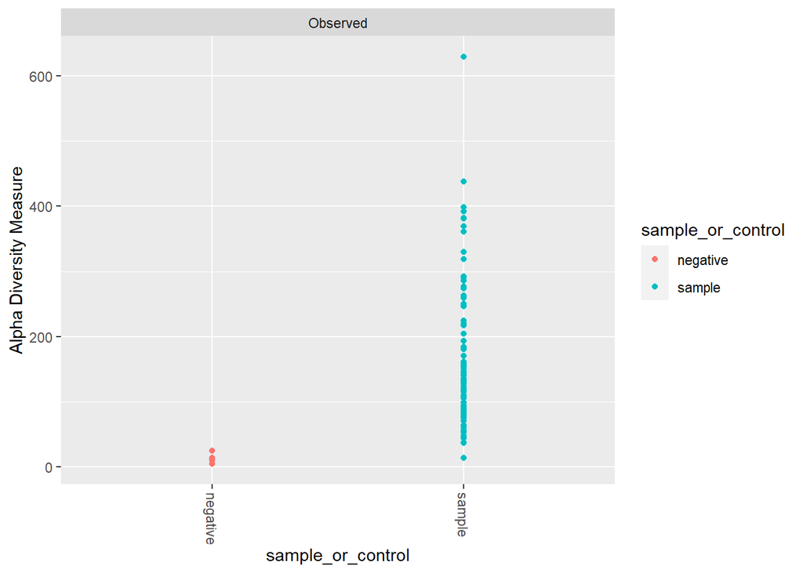

```r
# alpha diversity between the two
# names(ps_fecal_pt1_plate3@sam_data)
plot_richness(ps_fecal_pt1_plate3, x="sample_or_control", color="sample_or_control", measures=c("Observed"))
```

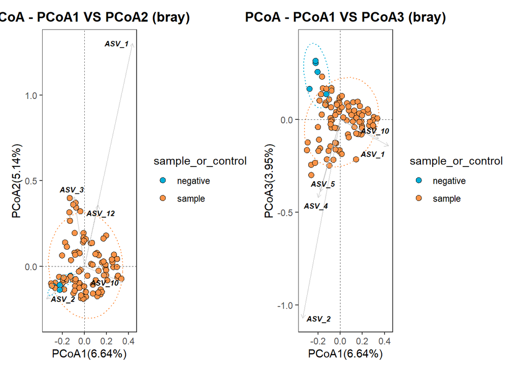

```r
# Beta diversity between the samples and negative controls
# this function is in MicrobiotaProcess
pcoares <- get_pcoa(obj=ps_fecal_pt1_plate3, distmethod="bray", method="hellinger")

pcoaplot1 <- ggordpoint(obj=pcoares, biplot=TRUE, speciesannot=TRUE,
                        factorNames=c("sample_or_control"), ellipse=TRUE) +
  scale_color_manual(values=c("#00AED7", "#FD9347")) +
  scale_fill_manual(values=c("#00AED7", "#FD9347"))
# first and third principal co-ordinates
pcoaplot2 <- ggordpoint(obj=pcoares, pc=c(1, 3), biplot=TRUE, speciesannot=TRUE,
                        factorNames=c("sample_or_control"), ellipse=TRUE) +
  scale_color_manual(values=c("#00AED7", "#FD9347")) +
  scale_fill_manual(values=c("#00AED7", "#FD9347"))
pcoa <- pcoaplot1 | pcoaplot2
pcoa
```

This plate looks very good! These data don’t match the data I found in my previous look. I wonder if there is an issue with my renaming system and if I misidentified the negative controls previously….